# Artificial Intelligence

## Computer Assignment 4 - Machine Learning

#### Amirali Raygan - 810197623

Using 1-day grace

### Phase 0

```python
import pandas as pd
import math
import matplotlib.pyplot as plt
from numpy.polynomial.polynomial import polyfit
import numpy as np
import seaborn as sns
from sklearn.preprocessing import MinMaxScaler
from sklearn import linear_model
from sklearn.neighbors import NearestNeighbors
```

```python
df = pd.read_csv("train.csv")
df.describe()
```

|  | Id | MSSubClass | LotFrontage | LotArea | OverallQual | OverallCond | YearBuilt | YearRemodAdd | MasVnrArea | BsmtFinSF1 | ... | WoodDeckSF | OpenPorchSF | EnclosedPorch | 3SsnPorch | ScreenPorch | PoolArea | MiscVal | MoSold | YrSold | SalePrice |
| --- | --- | --- | --- | --- | --- | --- | --- | --- | --- | --- | --- | --- | --- | --- | --- | --- | --- | --- | --- | --- | --- |
| count | 1460.000000 | 1460.000000 | 1201.000000 | 1460.000000 | 1460.000000 | 1460.000000 | 1460.000000 | 1460.000000 | 1452.000000 | 1460.000000 | ... | 1460.000000 | 1460.000000 | 1460.000000 | 1460.000000 | 1460.000000 | 1460.000000 | 1460.000000 | 1460.000000 | 1460.000000 | 1460.000000 |
| mean | 730.500000 | 56.897260 | 70.049958 | 10516.828082 | 6.099315 | 5.575342 | 1971.267808 | 1984.865753 | 103.685262 | 443.639726 | ... | 94.244521 | 46.660274 | 21.954110 | 3.409589 | 15.060959 | 2.758904 | 43.489041 | 6.321918 | 2007.815753 | 180921.195890 |
| std | 421.610009 | 42.300571 | 24.284752 | 9981.264932 | 1.382997 | 1.112799 | 30.202904 | 20.645407 | 181.066207 | 456.098091 | ... | 125.338794 | 66.256028 | 61.119149 | 29.317331 | 55.757415 | 40.177307 | 496.123024 | 2.703626 | 1.328095 | 79442.502883 |
| min | 1.000000 | 20.000000 | 21.000000 | 1300.000000 | 1.000000 | 1.000000 | 1872.000000 | 1950.000000 | 0.000000 | 0.000000 | ... | 0.000000 | 0.000000 | 0.000000 | 0.000000 | 0.000000 | 0.000000 | 0.000000 | 1.000000 | 2006.000000 | 34900.000000 |
| 25% | 365.750000 | 20.000000 | 59.000000 | 7553.500000 | 5.000000 | 5.000000 | 1954.000000 | 1967.000000 | 0.000000 | 0.000000 | ... | 0.000000 | 0.000000 | 0.000000 | 0.000000 | 0.000000 | 0.000000 | 0.000000 | 5.000000 | 2007.000000 | 129975.000000 |
| 50% | 730.500000 | 50.000000 | 69.000000 | 9478.500000 | 6.000000 | 5.000000 | 1973.000000 | 1994.000000 | 0.000000 | 383.500000 | ... | 0.000000 | 25.000000 | 0.000000 | 0.000000 | 0.000000 | 0.000000 | 0.000000 | 6.000000 | 2008.000000 | 163000.000000 |
| 75% | 1095.250000 | 70.000000 | 80.000000 | 11601.500000 | 7.000000 | 6.000000 | 2000.000000 | 2004.000000 | 166.000000 | 712.250000 | ... | 168.000000 | 68.000000 | 0.000000 | 0.000000 | 0.000000 | 0.000000 | 0.000000 | 8.000000 | 2009.000000 | 214000.000000 |
| max | 1460.000000 | 190.000000 | 313.000000 | 215245.000000 | 10.000000 | 9.000000 | 2010.000000 | 2010.000000 | 1600.000000 | 5644.000000 | ... | 857.000000 | 547.000000 | 552.000000 | 508.000000 | 480.000000 | 738.000000 | 15500.000000 | 12.000000 | 2010.000000 | 755000.000000 |

8 rows × 38 columns

```python
df.info()
```

```
<class 'pandas.core.frame.DataFrame'>
RangeIndex: 1460 entries, 0 to 1459
Data columns (total 81 columns):
Id               1460 non-null int64
MSSubClass       1460 non-null int64
MSZoning         1460 non-null object
LotFrontage      1201 non-null float64
LotArea          1460 non-null int64
Street           1460 non-null object
Alley            91 non-null object
LotShape         1460 non-null object
LandContour      1460 non-null object
Utilities        1460 non-null object
LotConfig        1460 non-null object
LandSlope        1460 non-null object
Neighborhood     1460 non-null object
Condition1       1460 non-null object
Condition2       1460 non-null object
BldgType         1460 non-null object
HouseStyle       1460 non-null object
OverallQual      1460 non-null int64
OverallCond      1460 non-null int64
YearBuilt        1460 non-null int64
YearRemodAdd     1460 non-null int64
RoofStyle        1460 non-null object
RoofMatl         1460 non-null object
Exterior1st      1460 non-null object
Exterior2nd      1460 non-null object
MasVnrType       1452 non-null object
MasVnrArea       1452 non-null float64
ExterQual        1460 non-null object
ExterCond        1460 non-null object
Foundation       1460 non-null object
BsmtQual         1423 non-null object
BsmtCond         1423 non-null object
BsmtExposure     1422 non-null object
BsmtFinType1     1423 non-null object
BsmtFinSF1       1460 non-null int64
BsmtFinType2     1422 non-null object
BsmtFinSF2       1460 non-null int64
```

[output cut: 31 more lines]

```
EnclosedPorch    1460 non-null int64
3SsnPorch        1460 non-null int64
ScreenPorch      1460 non-null int64
PoolArea         1460 non-null int64
PoolQC           7 non-null object
Fence            281 non-null object
MiscFeature      54 non-null object
MiscVal          1460 non-null int64
MoSold           1460 non-null int64
YrSold           1460 non-null int64
SaleType         1460 non-null object
SaleCondition    1460 non-null object
SalePrice        1460 non-null int64
dtypes: float64(3), int64(35), object(43)
memory usage: 924.0+ KB
```

```python
print("Mising data percentage per each feature: ")
(round( df.isnull().sum() / len(df) , 3) * 100 ).sort_values(ascending=False)
```

```
Mising data percentage per each feature:
```

```
PoolQC           99.5
MiscFeature      96.3
Alley            93.8
Fence            80.8
FireplaceQu      47.3
LotFrontage      17.7
GarageQual        5.5
GarageCond        5.5
GarageType        5.5
GarageYrBlt       5.5
GarageFinish      5.5
BsmtFinType2      2.6
BsmtExposure      2.6
BsmtQual          2.5
BsmtCond          2.5
BsmtFinType1      2.5
MasVnrArea        0.5
MasVnrType        0.5
Electrical        0.1
RoofMatl          0.0
RoofStyle         0.0
ExterQual         0.0
Exterior1st       0.0
Exterior2nd       0.0
YearBuilt         0.0
ExterCond         0.0
Foundation        0.0
YearRemodAdd      0.0
k2                0.0
OverallCond       0.0
                 ...
OpenPorchSF       0.0
EnclosedPorch     0.0
3SsnPorch         0.0
ScreenPorch       0.0
PoolArea          0.0
MiscVal           0.0
MoSold            0.0
YrSold            0.0
SaleType          0.0
SaleCondition     0.0
SalePrice         0.0
Fireplaces        0.0
Functional        0.0
TotRmsAbvGrd      0.0
LowQualFinSF      0.0
TotalBsmtSF       0.0
Heating           0.0
HeatingQC         0.0
k                 0.0
1stFlrSF          0.0
2ndFlrSF          0.0
GrLivArea         0.0
KitchenQual       0.0
BsmtFullBath      0.0
BsmtHalfBath      0.0
FullBath          0.0
HalfBath          0.0
BedroomAbvGr      0.0
KitchenAbvGr      0.0
Id                0.0
Length: 83, dtype: float64
```

In order to find relations between features, first of all we code the feature which contain string values, so that we can measure it with numbers and find correlation function.

```python
for i in df:
    if df[i].dtype == 'object':
        df[i] = df[i].astype('category').cat.codes
```

```python
corr = df.corr()
corr.style.background_gradient(cmap ='coolwarm')
```

|  | Id | MSSubClass | MSZoning | LotFrontage | LotArea | Street | Alley | LotShape | LandContour | Utilities | LotConfig | LandSlope | Neighborhood | Condition1 | Condition2 | BldgType | HouseStyle | OverallQual | OverallCond | YearBuilt | YearRemodAdd | RoofStyle | RoofMatl | Exterior1st | Exterior2nd | MasVnrType | MasVnrArea | ExterQual | ExterCond | … |
| --- | --- | --- | --- | --- | --- | --- | --- | --- | --- | --- | --- | --- | --- | --- | --- | --- | --- | --- | --- | --- | --- | --- | --- | --- | --- | --- | --- | --- | --- | --- |
| Id | 1 | 0.0111565 | -0.00609611 | -0.0106007 | -0.0332255 | 0.00891635 | -0.000292678 | 0.0321223 | -0.0196586 | 0.0133241 | 0.0497561 | 0.00584692 | -0.0137352 | -0.0038147 | 0.0018388 | 0.0219117 | 0.0181109 | -0.0283648 | 0.0126089 | -0.0127127 | -0.0219976 | 0.0386746 | -0.022562 | -0.0346939 | -0.0428466 | 0.0419254 | -0.0502978 | 0.00168894 | 0.0298263 | … |
| MSSubClass | 0.0111565 | 1 | 0.0359001 | -0.386347 | -0.139781 | -0.0249686 | 0.179144 | 0.119289 | -0.0029397 | -0.0228438 | 0.0759099 | -0.0256715 | -0.00598495 | -0.0247618 | -0.0423948 | 0.746063 | 0.397161 | 0.0326277 | -0.0593158 | 0.0278501 | 0.040581 | -0.117817 | -0.0313365 | -0.0891585 | -0.137229 | -0.0226928 | 0.0229363 | -0.0171615 | -0.003254 | … |
| MSZoning | -0.00609611 | 0.0359001 | 1 | -0.11169 | -0.0344516 | 0.0876539 | -0.191736 | 0.0618873 | -0.0178541 | -0.00119203 | -0.00989504 | -0.022055 | -0.249679 | -0.0278738 | 0.0446061 | 0.00569047 | -0.105315 | -0.160099 | 0.186951 | -0.308908 | -0.174728 | -0.000300673 | 0.00513268 | -0.00855849 | 0.00696259 | 0.00447976 | -0.0674866 | 0.200536 | -0.0960413 | … |
| LotFrontage | -0.0106007 | -0.386347 | -0.11169 | 1 | 0.426095 | -0.0408861 | -0.190957 | -0.169641 | -0.0807566 | nan | -0.208276 | 0.0883447 | 0.0930033 | -0.00925417 | 0.00372223 | -0.448537 | 0.0355017 | 0.251646 | -0.0592135 | 0.123349 | 0.0888656 | 0.169799 | 0.0957852 | 0.0812711 | 0.107308 | -0.0251625 | 0.193458 | -0.197128 | 0.0529437 | … |
| LotArea | -0.0332255 | -0.139781 | -0.0344516 | 0.426095 | 1 | -0.197131 | -0.0836682 | -0.165315 | -0.149083 | 0.0101232 | -0.121161 | 0.436868 | 0.0445694 | 0.0238462 | 0.0221641 | -0.205721 | -0.0331896 | 0.105806 | -0.00563627 | 0.0142277 | 0.0137884 | 0.0770543 | 0.149837 | 0.00425568 | -0.00392954 | -0.0121277 | 0.10416 | -0.0572746 | 0.0151596 | … |
| Street | 0.00891635 | -0.0249686 | 0.0876539 | -0.0408861 | -0.197131 | 1 | 0.0156115 | -0.010224 | 0.115995 | 0.00168177 | 0.0139603 | -0.17936 | -0.0115614 | -0.0716575 | 0.00203894 | -0.018243 | 0.0237037 | 0.0588232 | 0.0428484 | 0.0211368 | 0.0654648 | -0.0197316 | 0.00808097 | 0.00250512 | 0.00616592 | 0.00786869 | 0.0173261 | 0.0499758 | 0.00587407 | … |
| Alley | -0.000292678 | 0.179144 | -0.191736 | -0.190957 | -0.0836682 | 0.0156115 | 1 | 0.100107 | -0.077078 | -0.00636244 | 0.0470678 | -0.0215181 | 0.164709 | -0.0575918 | -0.00771368 | 0.139718 | -0.00776951 | -0.0267798 | 0.0381567 | -0.171859 | 0.0101448 | -0.0532805 | -0.0305718 | 0.016441 | 0.0286911 | 0.0470902 | -0.0200749 | 0.0179296 | -0.0272561 | … |
| LotShape | 0.0321223 | 0.119289 | 0.0618873 | -0.169641 | -0.165315 | -0.010224 | 0.100107 | 1 | 0.0854345 | -0.0361007 | 0.221102 | -0.0999509 | -0.038894 | -0.115003 | -0.0437677 | 0.116262 | -0.104026 | -0.190497 | 0.0136934 | -0.226062 | -0.153825 | 0.00318224 | -0.0711744 | -0.020463 | -0.027951 | 0.00199582 | -0.105847 | 0.148818 | -0.0294974 | … |
| LandContour | -0.0196586 | -0.0029397 | -0.0178541 | -0.0807566 | -0.149083 | 0.115995 | -0.077078 | 0.0854345 | 1 | 0.00823803 | -0.0255274 | -0.374267 | 0.0191164 | 0.024801 | -0.016185 | 0.0511428 | 0.0752338 | 0.0289073 | -0.0452707 | 0.161622 | 0.0933742 | -0.00424645 | -0.0202294 | -0.0118085 | -0.0340818 | -0.0802175 | 0.0493214 | -0.00361326 | 0.00980378 | … |
| Utilities | 0.0133241 | -0.0228438 | -0.00119203 | nan | 0.0101232 | 0.00168177 | -0.00636244 | -0.0361007 | 0.00823803 | 1 | -0.0325893 | -0.00590929 | 0.0468091 | -0.000950055 | -0.000830965 | -0.0107781 | 0.0542833 | -0.00188068 | 0.00999409 | -0.0115046 | -0.0340798 | -0.012868 | -0.00329338 | -0.0296863 | -0.0321004 | -0.0301926 | 0.0634268 | 0.0173693 | 0.00953501 | … |
| LotConfig | 0.0497561 | 0.0759099 | -0.00989504 | -0.208276 | -0.121161 | 0.0139603 | 0.0470678 | 0.221102 | -0.0255274 | -0.0325893 | 1 | -0.00725612 | -0.0365973 | 0.0214566 | 0.0338681 | 0.107229 | -0.0329455 | -0.0310863 | -0.0307879 | 0.0136288 | -0.00516079 | -0.0103641 | -0.0684648 | 0.0233163 | 0.00554611 | 7.51251e-05 | -0.03154 | -0.00250297 | 0.0348978 | … |
| LandSlope | 0.00584692 | -0.0256715 | -0.022055 | 0.0883447 | 0.436868 | -0.17936 | -0.0215181 | -0.0999509 | -0.374267 | -0.00590929 | -0.00725612 | 1 | -0.0804046 | -0.0167617 | -0.0263215 | -0.0535824 | -0.0317933 | -0.0664496 | 0.0103545 | -0.0736392 | -0.0591045 | -0.0277393 | 0.178678 | -0.0456603 | -0.0328783 | 0.0388263 | -0.0218154 | 0.0210405 | 0.00083371 | … |
| Neighborhood | -0.0137352 | -0.00598495 | -0.249679 | 0.0930033 | 0.0445694 | -0.0115614 | 0.164709 | -0.038894 | 0.0191164 | 0.0468091 | -0.0365973 | -0.0804046 | 1 | -0.0254007 | 0.0224318 | 0.00599347 | 0.0485945 | 0.196593 | -0.0336091 | 0.101289 | 0.102671 | 0.109937 | -0.00735256 | -0.0737176 | -0.0892216 | 0.0671621 | 0.119921 | -0.151595 | 0.0339178 | … |
| Condition1 | -0.0038147 | -0.0247618 | -0.0278738 | -0.00925417 | 0.0238462 | -0.0716575 | -0.0575918 | -0.115003 | 0.024801 | -0.000950055 | 0.0214566 | -0.0167617 | -0.0254007 | 1 | -0.0742677 | -0.0235015 | 0.0967142 | 0.100105 | -0.032243 | 0.158306 | 0.136622 | 0.00295573 | 0.00992404 | 0.0131457 | 0.00364932 | 0.00327997 | 0.0223045 | -0.0748545 | 0.076841 | … |
| Condition2 | 0.0018388 | -0.0423948 | 0.0446061 | 0.00372223 | 0.0221641 | 0.00203894 | -0.00771368 | -0.0437677 | -0.016185 | -0.000830965 | 0.0338681 | -0.0263215 | 0.0224318 | -0.0742677 | 1 | 0.00901393 | -0.02694 | 0.0149386 | 0.0144943 | 0.0288033 | 0.00751162 | 0.0414373 | -0.00399283 | -0.00537507 | -0.015751 | -0.00388794 | 0.0376704 | -0.0285058 | -0.0209804 | … |
| BldgType | 0.0219117 | 0.746063 | 0.00569047 | -0.448537 | -0.205721 | -0.018243 | 0.139718 | 0.116262 | 0.0511428 | -0.0107781 | 0.107229 | -0.0535824 | 0.00599347 | -0.0235015 | 0.00901393 | 1 | 0.0665519 | 0.0498343 | -0.16204 | 0.217584 | 0.104855 | -0.0543886 | -0.0384236 | -0.112112 | -0.142748 | -0.0274428 | 0.0433505 | -0.0878617 | 0.0850671 | … |
| HouseStyle | 0.0181109 | 0.397161 | -0.105315 | 0.0355017 | -0.0331896 | 0.0237037 | -0.00776951 | -0.104026 | 0.0752338 | 0.0542833 | -0.0329455 | -0.0317933 | 0.0485945 | 0.0967142 | -0.02694 | 0.0665519 | 1 | 0.21844 | -0.0313292 | 0.270494 | 0.209973 | -0.0326289 | 0.0453582 | -0.0364452 | -0.0710027 | -0.127908 | 0.169713 | -0.0926097 | 0.0675845 | … |
| OverallQual | -0.0283648 | 0.0326277 | -0.160099 | 0.251646 | 0.105806 | 0.0588232 | -0.0267798 | -0.190497 | 0.0289073 | -0.00188068 | -0.0310863 | -0.0664496 | 0.196593 | 0.100105 | 0.0149386 | 0.0498343 | 0.21844 | 1 | -0.0919323 | 0.572323 | 0.550684 | 0.167677 | 0.0745094 | 0.161406 | 0.152396 | -0.01697 | 0.411876 | -0.634319 | 0.138581 | … |
| OverallCond | 0.0126089 | -0.0593158 | 0.186951 | -0.0592135 | -0.00563627 | 0.0428484 | 0.0381567 | 0.0136934 | -0.0452707 | 0.00999409 | -0.0307879 | 0.0103545 | -0.0336091 | -0.032243 | 0.0144943 | -0.16204 | -0.0313292 | -0.0919323 | 1 | -0.375983 | 0.0737415 | -0.0100541 | 0.0274613 | -0.0411647 | -0.0280722 | 0.0251821 | -0.128101 | 0.169186 | -0.227407 | … |
| YearBuilt | -0.0127127 | 0.0278501 | -0.308908 | 0.123349 | 0.0142277 | 0.0211368 | -0.171859 | -0.226062 | 0.161622 | -0.0115046 | 0.0136288 | -0.0736392 | 0.101289 | 0.158306 | 0.0288033 | 0.217584 | 0.270494 | 0.572323 | -0.375983 | 1 | 0.592855 | 0.0489355 | -0.0209634 | 0.0972531 | 0.0757163 | -0.079924 | 0.315707 | -0.49422 | 0.26945 | … |
| YearRemodAdd | -0.0219976 | 0.040581 | -0.174728 | 0.0888656 | 0.0137884 | 0.0654648 | 0.0101448 | -0.153825 | 0.0933742 | -0.0340798 | -0.00516079 | -0.0591045 | 0.102671 | 0.136622 | 0.00751162 | 0.104855 | 0.209973 | 0.550684 | 0.0737415 | 0.592855 | 1 | 0.0277285 | -0.03326 | 0.23974 | 0.216372 | 0.0373144 | 0.179618 | -0.482496 | 0.0759769 | … |
| RoofStyle | 0.0386746 | -0.117817 | -0.000300673 | 0.169799 | 0.0770543 | -0.0197316 | -0.0532805 | 0.00318224 | -0.00424645 | -0.012868 | -0.0103641 | -0.0277393 | 0.109937 | 0.00295573 | 0.0414373 | -0.0543886 | -0.0326289 | 0.167677 | -0.0100541 | 0.0489355 | 0.0277285 | 1 | -0.0111388 | -0.0359817 | -0.0657254 | -0.0771231 | 0.249035 | -0.193143 | 0.0264674 | … |
| RoofMatl | -0.022562 | -0.0313365 | 0.00513268 | 0.0957852 | 0.149837 | 0.00808097 | -0.0305718 | -0.0711744 | -0.0202294 | -0.00329338 | -0.0684648 | 0.178678 | -0.00735256 | 0.00992404 | -0.00399283 | -0.0384236 | 0.0453582 | 0.0745094 | 0.0274613 | -0.0209634 | -0.03326 | -0.0111388 | 1 | -0.00275918 | -0.0133671 | -0.0142304 | 0.0349142 | -0.017094 | -0.0385995 | … |
| Exterior1st | -0.0346939 | -0.0891585 | -0.00855849 | 0.0812711 | 0.00425568 | 0.00250512 | 0.016441 | -0.020463 | -0.0118085 | -0.0296863 | 0.0233163 | -0.0456603 | -0.0737176 | 0.0131457 | -0.00537507 | -0.112112 | -0.0364452 | 0.161406 | -0.0411647 | 0.0972531 | 0.23974 | -0.0359817 | -0.00275918 | 1 | 0.854163 | 0.0231073 | 0.0244146 | -0.138748 | 0.0184501 | … |
| Exterior2nd | -0.0428466 | -0.137229 | 0.00696259 | 0.107308 | -0.00392954 | 0.00616592 | 0.0286911 | -0.027951 | -0.0340818 | -0.0321004 | 0.00554611 | -0.0328783 | -0.0892216 | 0.00364932 | -0.015751 | -0.142748 | -0.0710027 | 0.152396 | -0.0280722 | 0.0757163 | 0.216372 | -0.0657254 | -0.0133671 | 0.854163 | 1 | 0.0502788 | 0.00195747 | -0.114284 | 0.0315196 | … |
| MasVnrType | 0.0419254 | -0.0226928 | 0.00447976 | -0.0251625 | -0.0121277 | 0.00786869 | 0.0470902 | 0.00199582 | -0.0802175 | -0.0301926 | 7.51251e-05 | 0.0388263 | 0.0671621 | 0.00327997 | -0.00388794 | -0.0274428 | -0.127908 | -0.01697 | 0.0251821 | -0.079924 | 0.0373144 | -0.0771231 | -0.0142304 | 0.0231073 | 0.0502788 | 1 | -0.346673 | -0.0515367 | -0.0026761 | … |
| MasVnrArea | -0.0502978 | 0.0229363 | -0.0674866 | 0.193458 | 0.10416 | 0.0173261 | -0.0200749 | -0.105847 | 0.0493214 | 0.0634268 | -0.03154 | -0.0218154 | 0.119921 | 0.0223045 | 0.0376704 | 0.0433505 | 0.169713 | 0.411876 | -0.128101 | 0.315707 | 0.179618 | 0.249035 | 0.0349142 | 0.0244146 | 0.00195747 | -0.346673 | 1 | -0.359177 | 0.0708658 | … |
| ExterQual | 0.00168894 | -0.0171615 | 0.200536 | -0.197128 | -0.0572746 | 0.0499758 | 0.0179296 | 0.148818 | -0.00361326 | 0.0173693 | -0.00250297 | 0.0210405 | -0.151595 | -0.0748545 | -0.0285058 | -0.0878617 | -0.0926097 | -0.634319 | 0.169186 | -0.49422 | -0.482496 | -0.193143 | -0.017094 | -0.138748 | -0.114284 | -0.0515367 | -0.359177 | 1 | -0.0580939 | … |
| ExterCond | 0.0298263 | -0.003254 | -0.0960413 | 0.0529437 | 0.0151596 | 0.00587407 | -0.0272561 | -0.0294974 | 0.00980378 | 0.00953501 | 0.0348978 | 0.00083371 | 0.0339178 | 0.076841 | -0.0209804 | 0.0850671 | 0.0675845 | 0.138581 | -0.227407 | 0.26945 | 0.0759769 | 0.0264674 | -0.0385995 | 0.0184501 | 0.0315196 | -0.0026761 | 0.0708658 | -0.0580939 | 1 | … |
| Foundation | 0.00851439 | 0.0581264 | -0.235174 | 0.106156 | -0.0110813 | 0.0352772 | -0.0518767 | -0.135124 | 0.0534778 | -0.0143772 | -0.0117553 | -0.0277815 | 0.0664936 | 0.0740203 | -0.00644238 | 0.142892 | 0.186051 | 0.396186 | -0.294258 | 0.634842 | 0.438643 | 0.0232385 | -0.0279087 | 0.122936 | 0.117454 | -0.00274312 | 0.177715 | -0.413563 | 0.155928 | … |

[output cut: 51 more lines]

This is the heatmap of correlation distribution of all features of the dataset. The thing that is important to us is the 'SalePrice' row. It declares how each feature is effective on the final price. So here we have the values of this row in descending order.

```python
corr['SalePrice'].sort_values()
```

```
ExterQual       -0.636884
KitchenQual     -0.589189
BsmtQual        -0.438881
HeatingQC       -0.400178
GarageFinish    -0.292483
LotShape        -0.255580
GarageType      -0.223819
BsmtExposure    -0.193079
Fence           -0.181911
MSZoning        -0.166872
KitchenAbvGr    -0.135907
EnclosedPorch   -0.128578
Heating         -0.098812
Alley           -0.092607
BldgType        -0.085591
MSSubClass      -0.084284
OverallCond     -0.077856
MiscFeature     -0.069317
LotConfig       -0.067396
SaleType        -0.054911
YrSold          -0.028923
LowQualFinSF    -0.025606
Id              -0.021917
MiscVal         -0.021190
BsmtHalfBath    -0.016844
Utilities       -0.014314
BsmtFinType1    -0.013233
BsmtFinSF2      -0.011378
MasVnrType      -0.000488
Condition2       0.007513
                   ...
RoofStyle        0.222405
BsmtFullBath     0.227122
PavedDrive       0.231357
Electrical       0.233919
CentralAir       0.251328
GarageQual       0.261347
LotArea          0.263843
GarageCond       0.275781
HalfBath         0.284108
OpenPorchSF      0.315856
2ndFlrSF         0.319334
WoodDeckSF       0.324413
LotFrontage      0.351799
FireplaceQu      0.378377
Foundation       0.382479
BsmtFinSF1       0.386420
Fireplaces       0.466929
MasVnrArea       0.477493
GarageYrBlt      0.486362
YearRemodAdd     0.507101
YearBuilt        0.522897
TotRmsAbvGrd     0.533723
FullBath         0.560664
1stFlrSF         0.605852
TotalBsmtSF      0.613581
GarageArea       0.623431
GarageCars       0.640409
GrLivArea        0.708624
OverallQual      0.790982
SalePrice        1.000000
Name: SalePrice, Length: 81, dtype: float64
```

The most affective features are ones that are closer to 1 or -1 which represent the linear relation between features. As it shown, the 4 most affective features are:

### 1- OverallQual

### 2- GrLivArea

### 3- GarageCars

### 4- ExterQual

```python
for i in range(len(df)):
    df['SalePrice'][i] = math.log(df['SalePrice'][i])
corr = df.corr()
corr.style.background_gradient(cmap ='coolwarm')
```

|  | Id | MSSubClass | LotFrontage | LotArea | OverallQual | OverallCond | YearBuilt | YearRemodAdd | MasVnrArea | BsmtFinSF1 | BsmtFinSF2 | BsmtUnfSF | TotalBsmtSF | 1stFlrSF | 2ndFlrSF | LowQualFinSF | GrLivArea | BsmtFullBath | BsmtHalfBath | FullBath | HalfBath | BedroomAbvGr | KitchenAbvGr | TotRmsAbvGrd | Fireplaces | GarageYrBlt | GarageCars | GarageArea | WoodDeckSF | … |
| --- | --- | --- | --- | --- | --- | --- | --- | --- | --- | --- | --- | --- | --- | --- | --- | --- | --- | --- | --- | --- | --- | --- | --- | --- | --- | --- | --- | --- | --- | --- |
| Id | 1 | 0.0111565 | -0.0106007 | -0.0332255 | -0.0283648 | 0.0126089 | -0.0127127 | -0.0219976 | -0.0502978 | -0.00502405 | -0.00596767 | -0.0079397 | -0.0154146 | 0.010496 | 0.00558985 | -0.04423 | 0.00827276 | 0.00228856 | -0.0201547 | 0.00558745 | 0.00678381 | 0.0377186 | 0.00295124 | 0.0272387 | -0.0197716 | 7.23902e-05 | 0.0165697 | 0.0176338 | -0.0296432 | … |
| MSSubClass | 0.0111565 | 1 | -0.386347 | -0.139781 | 0.0326277 | -0.0593158 | 0.0278501 | 0.040581 | 0.0229363 | -0.0698357 | -0.0656486 | -0.140759 | -0.238518 | -0.251758 | 0.307886 | 0.0464738 | 0.0748532 | 0.00349103 | -0.00233253 | 0.131608 | 0.177354 | -0.023438 | 0.281721 | 0.0403801 | -0.0455693 | 0.0850719 | -0.0401098 | -0.0986715 | -0.0125794 | … |
| LotFrontage | -0.0106007 | -0.386347 | 1 | 0.426095 | 0.251646 | -0.0592135 | 0.123349 | 0.0888656 | 0.193458 | 0.233633 | 0.0498997 | 0.132644 | 0.392075 | 0.457181 | 0.0801773 | 0.0384685 | 0.402797 | 0.100949 | -0.0072343 | 0.198769 | 0.0535319 | 0.26317 | -0.00606883 | 0.352096 | 0.266639 | 0.0702498 | 0.285691 | 0.344997 | 0.0885209 | … |
| LotArea | -0.0332255 | -0.139781 | 0.426095 | 1 | 0.105806 | -0.00563627 | 0.0142277 | 0.0137884 | 0.10416 | 0.214103 | 0.11117 | -0.00261836 | 0.260833 | 0.299475 | 0.0509859 | 0.00477897 | 0.263116 | 0.158155 | 0.0480456 | 0.126031 | 0.0142595 | 0.11969 | -0.0177839 | 0.190015 | 0.271364 | -0.0249474 | 0.154871 | 0.180403 | 0.171698 | … |
| OverallQual | -0.0283648 | 0.0326277 | 0.251646 | 0.105806 | 1 | -0.0919323 | 0.572323 | 0.550684 | 0.411876 | 0.239666 | -0.0591187 | 0.308159 | 0.537808 | 0.476224 | 0.295493 | -0.0304293 | 0.593007 | 0.111098 | -0.0401502 | 0.5506 | 0.273458 | 0.101676 | -0.183882 | 0.427452 | 0.396765 | 0.547766 | 0.600671 | 0.562022 | 0.238923 | … |
| OverallCond | 0.0126089 | -0.0593158 | -0.0592135 | -0.00563627 | -0.0919323 | 1 | -0.375983 | 0.0737415 | -0.128101 | -0.0462309 | 0.0402292 | -0.136841 | -0.171098 | -0.144203 | 0.0289421 | 0.0254943 | -0.0796859 | -0.0549415 | 0.117821 | -0.194149 | -0.0607693 | 0.0129801 | -0.0870009 | -0.0575832 | -0.02382 | -0.324297 | -0.185758 | -0.151521 | -0.0033337 | … |
| YearBuilt | -0.0127127 | 0.0278501 | 0.123349 | 0.0142277 | 0.572323 | -0.375983 | 1 | 0.592855 | 0.315707 | 0.249503 | -0.0491068 | 0.14904 | 0.391452 | 0.281986 | 0.0103077 | -0.183784 | 0.19901 | 0.187599 | -0.0381618 | 0.468271 | 0.242656 | -0.0706512 | -0.1748 | 0.0955891 | 0.147716 | 0.825667 | 0.53785 | 0.478954 | 0.22488 | … |
| YearRemodAdd | -0.0219976 | 0.040581 | 0.0888656 | 0.0137884 | 0.550684 | 0.0737415 | 0.592855 | 1 | 0.179618 | 0.128451 | -0.0677585 | 0.181133 | 0.291066 | 0.240379 | 0.140024 | -0.0624191 | 0.287389 | 0.11947 | -0.012337 | 0.439046 | 0.183331 | -0.0405809 | -0.149598 | 0.19174 | 0.112581 | 0.642277 | 0.420622 | 0.3716 | 0.205726 | … |
| MasVnrArea | -0.0502978 | 0.0229363 | 0.193458 | 0.10416 | 0.411876 | -0.128101 | 0.315707 | 0.179618 | 1 | 0.264736 | -0.0723188 | 0.114442 | 0.363936 | 0.344501 | 0.174561 | -0.0690709 | 0.390857 | 0.0853098 | 0.0266728 | 0.276833 | 0.201444 | 0.102821 | -0.0376103 | 0.280682 | 0.24907 | 0.252691 | 0.364204 | 0.373066 | 0.159718 | … |
| BsmtFinSF1 | -0.00502405 | -0.0698357 | 0.233633 | 0.214103 | 0.239666 | -0.0462309 | 0.249503 | 0.128451 | 0.264736 | 1 | -0.0501174 | -0.495251 | 0.522396 | 0.445863 | -0.137079 | -0.0645026 | 0.208171 | 0.649212 | 0.0674185 | 0.0585431 | 0.00426242 | -0.107355 | -0.0810069 | 0.0443156 | 0.260011 | 0.153484 | 0.224054 | 0.29697 | 0.204306 | … |
| BsmtFinSF2 | -0.00596767 | -0.0656486 | 0.0498997 | 0.11117 | -0.0591187 | 0.0402292 | -0.0491068 | -0.0677585 | -0.0723188 | -0.0501174 | 1 | -0.209294 | 0.10481 | 0.0971174 | -0.0992603 | 0.014807 | -0.00963989 | 0.158678 | 0.0709481 | -0.0764439 | -0.0321478 | -0.0157281 | -0.0407512 | -0.0352265 | 0.0469207 | -0.0880108 | -0.0382635 | -0.0182266 | 0.0678983 | … |
| BsmtUnfSF | -0.0079397 | -0.140759 | 0.132644 | -0.00261836 | 0.308159 | -0.136841 | 0.14904 | 0.181133 | 0.114442 | -0.495251 | -0.209294 | 1 | 0.41536 | 0.317987 | 0.00446909 | 0.0281667 | 0.240257 | -0.4229 | -0.0958043 | 0.288886 | -0.0411175 | 0.166643 | 0.0300859 | 0.250647 | 0.0515749 | 0.190708 | 0.214175 | 0.183303 | -0.00531642 | … |
| TotalBsmtSF | -0.0154146 | -0.238518 | 0.392075 | 0.260833 | 0.537808 | -0.171098 | 0.391452 | 0.291066 | 0.363936 | 0.522396 | 0.10481 | 0.41536 | 1 | 0.81953 | -0.174512 | -0.0332454 | 0.454868 | 0.307351 | -0.000314582 | 0.323722 | -0.0488037 | 0.05045 | -0.0689006 | 0.285573 | 0.339519 | 0.322445 | 0.434585 | 0.486665 | 0.232019 | … |
| 1stFlrSF | 0.010496 | -0.251758 | 0.457181 | 0.299475 | 0.476224 | -0.144203 | 0.281986 | 0.240379 | 0.344501 | 0.445863 | 0.0971174 | 0.317987 | 0.81953 | 1 | -0.202646 | -0.0142407 | 0.566024 | 0.244671 | 0.00195565 | 0.380637 | -0.119916 | 0.127401 | 0.0681006 | 0.409516 | 0.410531 | 0.233449 | 0.439317 | 0.489782 | 0.235459 | … |
| 2ndFlrSF | 0.00558985 | 0.307886 | 0.0801773 | 0.0509859 | 0.295493 | 0.0289421 | 0.0103077 | 0.140024 | 0.174561 | -0.137079 | -0.0992603 | 0.00446909 | -0.174512 | -0.202646 | 1 | 0.063353 | 0.687501 | -0.169494 | -0.0238548 | 0.421378 | 0.609707 | 0.502901 | 0.0593058 | 0.616423 | 0.194561 | 0.0708323 | 0.183926 | 0.138347 | 0.0921654 | … |
| LowQualFinSF | -0.04423 | 0.0464738 | 0.0384685 | 0.00477897 | -0.0304293 | 0.0254943 | -0.183784 | -0.0624191 | -0.0690709 | -0.0645026 | 0.014807 | 0.0281667 | -0.0332454 | -0.0142407 | 0.063353 | 1 | 0.134683 | -0.0471434 | -0.0058415 | -0.00070951 | -0.02708 | 0.105607 | 0.00752174 | 0.131185 | -0.0212721 | -0.0363632 | -0.0944795 | -0.0676014 | -0.0254436 | … |
| GrLivArea | 0.00827276 | 0.0748532 | 0.402797 | 0.263116 | 0.593007 | -0.0796859 | 0.19901 | 0.287389 | 0.390857 | 0.208171 | -0.00963989 | 0.240257 | 0.454868 | 0.566024 | 0.687501 | 0.134683 | 1 | 0.034836 | -0.0189185 | 0.630012 | 0.415772 | 0.52127 | 0.100063 | 0.825489 | 0.461679 | 0.231197 | 0.467247 | 0.468997 | 0.247433 | … |
| BsmtFullBath | 0.00228856 | 0.00349103 | 0.100949 | 0.158155 | 0.111098 | -0.0549415 | 0.187599 | 0.11947 | 0.0853098 | 0.649212 | 0.158678 | -0.4229 | 0.307351 | 0.244671 | -0.169494 | -0.0471434 | 0.034836 | 1 | -0.147871 | -0.064512 | -0.030905 | -0.150673 | -0.0415025 | -0.0532752 | 0.137928 | 0.124553 | 0.131881 | 0.179189 | 0.175315 | … |
| BsmtHalfBath | -0.0201547 | -0.00233253 | -0.0072343 | 0.0480456 | -0.0401502 | 0.117821 | -0.0381618 | -0.012337 | 0.0266728 | 0.0674185 | 0.0709481 | -0.0958043 | -0.000314582 | 0.00195565 | -0.0238548 | -0.0058415 | -0.0189185 | -0.147871 | 1 | -0.0545358 | -0.0123399 | 0.0465188 | -0.0379444 | -0.0238363 | 0.0289756 | -0.0774636 | -0.0208911 | -0.0245356 | 0.0401612 | … |
| FullBath | 0.00558745 | 0.131608 | 0.198769 | 0.126031 | 0.5506 | -0.194149 | 0.468271 | 0.439046 | 0.276833 | 0.0585431 | -0.0764439 | 0.288886 | 0.323722 | 0.380637 | 0.421378 | -0.00070951 | 0.630012 | -0.064512 | -0.0545358 | 1 | 0.136381 | 0.363252 | 0.133115 | 0.554784 | 0.243671 | 0.484557 | 0.469672 | 0.405656 | 0.187703 | … |
| HalfBath | 0.00678381 | 0.177354 | 0.0535319 | 0.0142595 | 0.273458 | -0.0607693 | 0.242656 | 0.183331 | 0.201444 | 0.00426242 | -0.0321478 | -0.0411175 | -0.0488037 | -0.119916 | 0.609707 | -0.02708 | 0.415772 | -0.030905 | -0.0123399 | 0.136381 | 1 | 0.226651 | -0.0682625 | 0.343415 | 0.203649 | 0.196785 | 0.219178 | 0.163549 | 0.10808 | … |
| BedroomAbvGr | 0.0377186 | -0.023438 | 0.26317 | 0.11969 | 0.101676 | 0.0129801 | -0.0706512 | -0.0405809 | 0.102821 | -0.107355 | -0.0157281 | 0.166643 | 0.05045 | 0.127401 | 0.502901 | 0.105607 | 0.52127 | -0.150673 | 0.0465188 | 0.363252 | 0.226651 | 1 | 0.198597 | 0.67662 | 0.10757 | -0.0645184 | 0.0861064 | 0.0652525 | 0.0468538 | … |
| KitchenAbvGr | 0.00295124 | 0.281721 | -0.00606883 | -0.0177839 | -0.183882 | -0.0870009 | -0.1748 | -0.149598 | -0.0376103 | -0.0810069 | -0.0407512 | 0.0300859 | -0.0689006 | 0.0681006 | 0.0593058 | 0.00752174 | 0.100063 | -0.0415025 | -0.0379444 | 0.133115 | -0.0682625 | 0.198597 | 1 | 0.256045 | -0.123936 | -0.124411 | -0.0506339 | -0.064433 | -0.0901303 | … |
| TotRmsAbvGrd | 0.0272387 | 0.0403801 | 0.352096 | 0.190015 | 0.427452 | -0.0575832 | 0.0955891 | 0.19174 | 0.280682 | 0.0443156 | -0.0352265 | 0.250647 | 0.285573 | 0.409516 | 0.616423 | 0.131185 | 0.825489 | -0.0532752 | -0.0238363 | 0.554784 | 0.343415 | 0.67662 | 0.256045 | 1 | 0.326114 | 0.148112 | 0.362289 | 0.337822 | 0.165984 | … |
| Fireplaces | -0.0197716 | -0.0455693 | 0.266639 | 0.271364 | 0.396765 | -0.02382 | 0.147716 | 0.112581 | 0.24907 | 0.260011 | 0.0469207 | 0.0515749 | 0.339519 | 0.410531 | 0.194561 | -0.0212721 | 0.461679 | 0.137928 | 0.0289756 | 0.243671 | 0.203649 | 0.10757 | -0.123936 | 0.326114 | 1 | 0.0468216 | 0.300789 | 0.269141 | 0.200019 | … |
| GarageYrBlt | 7.23902e-05 | 0.0850719 | 0.0702498 | -0.0249474 | 0.547766 | -0.324297 | 0.825667 | 0.642277 | 0.252691 | 0.153484 | -0.0880108 | 0.190708 | 0.322445 | 0.233449 | 0.0708323 | -0.0363632 | 0.231197 | 0.124553 | -0.0774636 | 0.484557 | 0.196785 | -0.0645184 | -0.124411 | 0.148112 | 0.0468216 | 1 | 0.58892 | 0.564567 | 0.224577 | … |
| GarageCars | 0.0165697 | -0.0401098 | 0.285691 | 0.154871 | 0.600671 | -0.185758 | 0.53785 | 0.420622 | 0.364204 | 0.224054 | -0.0382635 | 0.214175 | 0.434585 | 0.439317 | 0.183926 | -0.0944795 | 0.467247 | 0.131881 | -0.0208911 | 0.469672 | 0.219178 | 0.0861064 | -0.0506339 | 0.362289 | 0.300789 | 0.58892 | 1 | 0.882475 | 0.226342 | … |
| GarageArea | 0.0176338 | -0.0986715 | 0.344997 | 0.180403 | 0.562022 | -0.151521 | 0.478954 | 0.3716 | 0.373066 | 0.29697 | -0.0182266 | 0.183303 | 0.486665 | 0.489782 | 0.138347 | -0.0676014 | 0.468997 | 0.179189 | -0.0245356 | 0.405656 | 0.163549 | 0.0652525 | -0.064433 | 0.337822 | 0.269141 | 0.564567 | 0.882475 | 1 | 0.224666 | … |
| WoodDeckSF | -0.0296432 | -0.0125794 | 0.0885209 | 0.171698 | 0.238923 | -0.0033337 | 0.22488 | 0.205726 | 0.159718 | 0.204306 | 0.0678983 | -0.00531642 | 0.232019 | 0.235459 | 0.0921654 | -0.0254436 | 0.247433 | 0.175315 | 0.0401612 | 0.187703 | 0.10808 | 0.0468538 | -0.0901303 | 0.165984 | 0.200019 | 0.224577 | 0.226342 | 0.224666 | 1 | … |
| OpenPorchSF | -0.000476911 | -0.00610012 | 0.151972 | 0.0847738 | 0.308819 | -0.0325888 | 0.188686 | 0.226298 | 0.125703 | 0.111761 | 0.00309256 | 0.129005 | 0.247264 | 0.211671 | 0.208026 | 0.018251 | 0.330224 | 0.0673415 | -0.0253238 | 0.259977 | 0.19974 | 0.0938096 | -0.0700906 | 0.234192 | 0.169405 | 0.228425 | 0.213569 | 0.241435 | 0.0586606 | … |
| EnclosedPorch | 0.00288922 | -0.0120366 | 0.0107003 | -0.0183397 | -0.113937 | 0.0703562 | -0.387268 | -0.193919 | -0.110204 | -0.102303 | 0.0365433 | -0.00253785 | -0.0954777 | -0.0652917 | 0.0619887 | 0.0610812 | 0.00911321 | -0.0499106 | -0.00855533 | -0.115093 | -0.0953165 | 0.0415704 | 0.0373124 | 0.0041513 | -0.0248219 | -0.297003 | -0.151434 | -0.121777 | -0.125989 | … |
| 3SsnPorch | -0.0466348 | -0.0438245 | 0.0700292 | 0.0204228 | 0.0303706 | 0.0255037 | 0.0313545 | 0.0452858 | 0.0187955 | 0.0264505 | -0.0299934 | 0.020764 | 0.0373837 | 0.0561044 | -0.0243576 | -0.00429561 | 0.0206432 | -0.000106092 | 0.0351136 | 0.035353 | -0.00497249 | -0.0244778 | -0.0246004 | -0.00668324 | 0.0112572 | 0.0235437 | 0.0357653 | 0.0350867 | -0.0327706 | … |
| ScreenPorch | 0.00133021 | -0.0260302 | 0.0413828 | 0.0431604 | 0.0648864 | 0.0548105 | -0.0503644 | -0.03874 | 0.0614655 | 0.0620206 | 0.0888713 | -0.0125793 | 0.084489 | 0.0887581 | 0.0406064 | 0.0267994 | 0.10151 | 0.0231477 | 0.0321214 | -0.00810609 | 0.0724258 | 0.0442997 | -0.0516134 | 0.0593826 | 0.18453 | -0.0754175 | 0.0504938 | 0.0514118 | -0.0741814 | … |
| PoolArea | 0.0570439 | 0.00828271 | 0.206167 | 0.0776724 | 0.0651658 | -0.00198494 | 0.00494973 | 0.00582937 | 0.0117231 | 0.140491 | 0.0417091 | -0.0350922 | 0.126053 | 0.131525 | 0.0814869 | 0.0621574 | 0.170205 | 0.0676156 | 0.0200246 | 0.0496038 | 0.0223815 | 0.0707026 | -0.0145251 | 0.0837573 | 0.0950735 | -0.0145007 | 0.0209335 | 0.0610473 | 0.0733782 | … |
| MiscVal | -0.0062424 | -0.00768329 | 0.00336756 | 0.0380677 | -0.0314062 | 0.0687768 | -0.0343831 | -0.0102862 | -0.0298154 | 0.00357147 | 0.00493978 | -0.0238366 | -0.0184789 | -0.0210957 | 0.0161969 | -0.00379287 | -0.00241564 | -0.023047 | -0.00736652 | -0.0142898 | 0.00129014 | 0.00776697 | 0.0623407 | 0.0247629 | 0.00140861 | -0.0324175 | -0.0430801 | -0.0273999 | -0.00955123 | … |
| MoSold | 0.0211722 | -0.0135846 | 0.0112 | 0.00120499 | 0.0708152 | -0.00351084 | 0.0123985 | 0.02149 | -0.00596472 | -0.0157269 | -0.0152107 | 0.0348884 | 0.0131962 | 0.0313716 | 0.0351644 | -0.022174 | 0.0502397 | -0.0253609 | 0.0328727 | 0.0558721 | -0.00904989 | 0.0465439 | 0.0265889 | 0.0369071 | 0.0463571 | 0.00533703 | 0.0405217 | 0.0279738 | 0.021011 | … |
| YrSold | 0.000711794 | -0.021407 | 0.00744959 | -0.0142614 | -0.0273467 | 0.0439497 | -0.0136177 | 0.0357432 | -0.00820103 | 0.0143589 | 0.0317056 | -0.0412582 | -0.0149686 | -0.0136038 | -0.0286999 | -0.0289209 | -0.0365258 | 0.0670491 | -0.0465239 | -0.0196688 | -0.0102687 | -0.0360139 | 0.0316872 | -0.0345164 | -0.0240956 | -0.00101428 | -0.0391169 | -0.0273779 | 0.0222705 | … |
| SalePrice | -0.0146302 | -0.0298604 | 0.283706 | 0.199319 | 0.70429 | -0.117062 | 0.559719 | 0.522901 | 0.332923 | 0.231093 | -0.0136334 | 0.232813 | 0.469733 | 0.464546 | 0.316806 | -0.0139557 | 0.603646 | 0.133663 | -0.00784176 | 0.621326 | 0.319804 | 0.158058 | -0.159277 | 0.451872 | 0.438722 | 0.514622 | 0.593373 | 0.529677 | 0.273146 | … |

```python
corr['SalePrice'].sort_values()
```

[output not shown]

When we use the Logarithm of SalePrice instead of the actual value the differences between big values bemcome tinier and so the accuaracy of correlation and also heatmap plot become unseparatable. Result of the previous heatmap is more countable.

One of the problems with heatmap is wrong data.This may cause noise in the results. And also heatmap is not sufficient for all features. specificly features which work with describes and not numbers.

```python
df = pd.read_csv("train.csv")
```

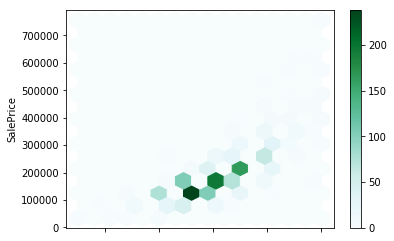

```python
## Hexbin plot for OverallQual over SalePrice
plt =df.plot(kind='hexbin',x='OverallQual',y='SalePrice', gridsize=15)
```

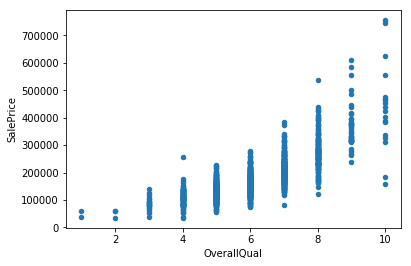

```python
## Scatter plot for OverallQual over SalePrice
plt =df.plot(kind='scatter',x='OverallQual',y='SalePrice')
```

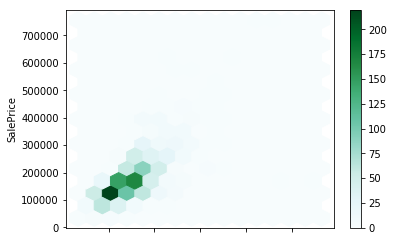

```python
## Hexbin plot for GrLivArea over SalePrice
plt =df.plot(kind='hexbin',x='GrLivArea',y='SalePrice', gridsize=15)
```

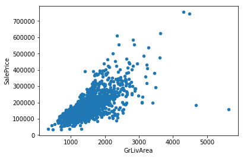

```python
## Scatter plot for GrLivArea over SalePrice
plt =df.plot(kind='scatter',x='GrLivArea',y='SalePrice')
```

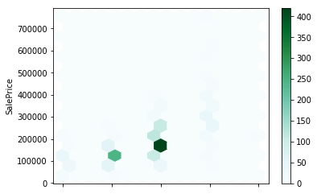

```python
## Hexbin plot for GarageCars over SalePrice
plt =df.plot(kind='hexbin',x='GarageCars',y='SalePrice', gridsize=15)
```

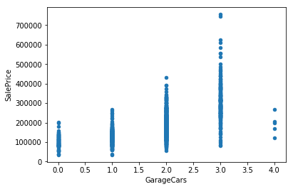

```python
## Scatter plot for GarageCars over SalePrice
plt =df.plot(kind='scatter',x='GarageCars',y='SalePrice')
```

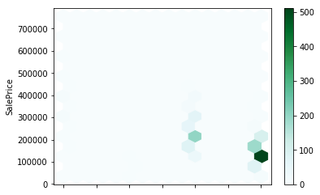

```python
## Hexbin plot for ExterQual over SalePrice
plt =df.plot(kind='hexbin',x='ExterQual',y='SalePrice', gridsize=15)
```

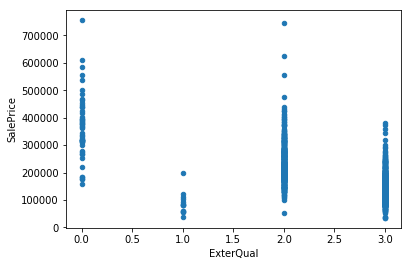

```python
## Scatter plot for ExterQual over SalePrice
plt =df.plot(kind='scatter',x='ExterQual',y='SalePrice')
```

## Phase 1

There are several ways to get along with missing data.When the rate of missing data in a feature is remarkable and it can cause great error in our conclusion it is better to completly delete that feature.But when there are only a few number of missing data it is better to replace them by a value. One of the topic in this case is "Deductive Imputation" which contains the algorithms that replace missing data with a statistical value representing the whole data. We can replace Nan values in dataframe with various variables. First, we can use mean/median of the feature for replacement. This is helpful for replacing small amount of missing data which are not far from each other.

In these plots we represent missing data replaced values by red color.

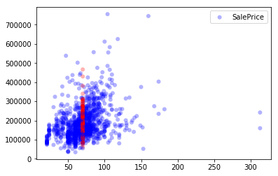

```python
## Missing data replace by Mean
fig, ax = plt.subplots()
sub = df['LotFrontage'].isnull()
k = df['LotFrontage']
k = k.fillna(df['LotFrontage'].mean())
colors = {True:"Red", False:"Blue"}
ax.scatter(k, df['SalePrice'], c=df['LotFrontage'].isnull().map(colors), alpha=0.3, edgecolors='none')
plt.legend()
plt.show()
```

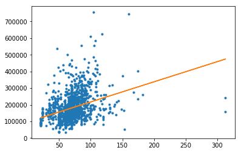

```python
## Missing data replace by Mean
fig, ax = plt.subplots()
sub = df['LotFrontage'].isnull()
k = df['LotFrontage']

x = df['LotFrontage']
x = x.fillna(x.mean())
y = df['SalePrice']
b, m = polyfit(x, y, 1)
plt.plot(x, y, '.')
plt.plot(x, b + m * x, '-')

plt.show()
```

We can also draw a linear regression in the plot and replace each missing value with the pairing match point on the line. Using this method we can predict our missing values more efficiently and make a better prediction.

According to list of missing data in our dataframe(shown in previous cells) these features contains the most missing data.

```
   Feature          Percentage of missing data
1. PoolQC           99.5
2. MiscFeature      96.3
3. Alley            93.8
4. Fence            80.8
5. FireplaceQu      47.3
```

In order to handle missing data first we take a look at feature descriptions. In the 'PoolQC' feature we can find out that NA value means the house do not have pool. so we replaced it with -1.

```python
df[df['PoolQC']!=-1].head(5)
```

|  | Id | MSSubClass | MSZoning | LotFrontage | LotArea | Street | Alley | LotShape | LandContour | Utilities | ... | PoolArea | PoolQC | Fence | MiscFeature | MiscVal | MoSold | YrSold | SaleType | SaleCondition | SalePrice |
| --- | --- | --- | --- | --- | --- | --- | --- | --- | --- | --- | --- | --- | --- | --- | --- | --- | --- | --- | --- | --- | --- |
| 197 | 198 | 75 | 3 | 174.0 | 25419 | 1 | -1 | 3 | 3 | 0 | ... | 512 | 0 | 0 | -1 | 0 | 3 | 2006 | 8 | 0 | 235000 |
| 810 | 811 | 20 | 3 | 78.0 | 10140 | 1 | -1 | 3 | 3 | 0 | ... | 648 | 1 | 0 | -1 | 0 | 1 | 2006 | 8 | 4 | 181000 |
| 1170 | 1171 | 80 | 3 | 76.0 | 9880 | 1 | -1 | 3 | 3 | 0 | ... | 576 | 2 | 0 | -1 | 0 | 7 | 2008 | 8 | 4 | 171000 |
| 1182 | 1183 | 60 | 3 | 160.0 | 15623 | 1 | -1 | 0 | 3 | 0 | ... | 555 | 0 | 2 | -1 | 0 | 7 | 2007 | 8 | 0 | 745000 |
| 1298 | 1299 | 60 | 3 | 313.0 | 63887 | 1 | -1 | 2 | 0 | 0 | ... | 480 | 2 | -1 | -1 | 0 | 1 | 2008 | 6 | 5 | 160000 |

5 rows × 81 columns

Also in the 'MiscFeature' feature NA means there is nothing special about the house that doesn't refer in other features. So again we assume -1 value means nothing special about the house.

```python
df[df['MiscFeature']!=-1].head(5)
```

|  | Id | MSSubClass | MSZoning | LotFrontage | LotArea | Street | Alley | LotShape | LandContour | Utilities | ... | PoolArea | PoolQC | Fence | MiscFeature | MiscVal | MoSold | YrSold | SaleType | SaleCondition | SalePrice |
| --- | --- | --- | --- | --- | --- | --- | --- | --- | --- | --- | --- | --- | --- | --- | --- | --- | --- | --- | --- | --- | --- |
| 5 | 6 | 50 | 3 | 85.0 | 14115 | 1 | -1 | 0 | 3 | 0 | ... | 0 | -1 | 2 | 2 | 700 | 10 | 2009 | 8 | 4 | 143000 |
| 7 | 8 | 60 | 3 | NaN | 10382 | 1 | -1 | 0 | 3 | 0 | ... | 0 | -1 | -1 | 2 | 350 | 11 | 2009 | 8 | 4 | 200000 |
| 16 | 17 | 20 | 3 | NaN | 11241 | 1 | -1 | 0 | 3 | 0 | ... | 0 | -1 | -1 | 2 | 700 | 3 | 2010 | 8 | 4 | 149000 |
| 17 | 18 | 90 | 3 | 72.0 | 10791 | 1 | -1 | 3 | 3 | 0 | ... | 0 | -1 | -1 | 2 | 500 | 10 | 2006 | 8 | 4 | 90000 |
| 51 | 52 | 50 | 4 | 52.0 | 6240 | 1 | -1 | 3 | 3 | 0 | ... | 0 | -1 | 2 | 2 | 400 | 9 | 2006 | 8 | 4 | 114500 |

5 rows × 81 columns

For the feature 'Alley' NA value means there is no alley access to the house. So as previous we assume -1 to no valley access.

```python
df[df['Alley']!=-1].head(5)
```

|  | Id | MSSubClass | MSZoning | LotFrontage | LotArea | Street | Alley | LotShape | LandContour | Utilities | ... | PoolArea | PoolQC | Fence | MiscFeature | MiscVal | MoSold | YrSold | SaleType | SaleCondition | SalePrice |
| --- | --- | --- | --- | --- | --- | --- | --- | --- | --- | --- | --- | --- | --- | --- | --- | --- | --- | --- | --- | --- | --- |
| 21 | 22 | 45 | 4 | 57.0 | 7449 | 1 | 0 | 3 | 0 | 0 | ... | 0 | -1 | 0 | -1 | 0 | 6 | 2007 | 8 | 4 | 139400 |
| 30 | 31 | 70 | 0 | 50.0 | 8500 | 1 | 1 | 3 | 3 | 0 | ... | 0 | -1 | 2 | -1 | 0 | 7 | 2008 | 8 | 4 | 40000 |
| 56 | 57 | 160 | 1 | 24.0 | 2645 | 1 | 1 | 3 | 3 | 0 | ... | 0 | -1 | -1 | -1 | 0 | 8 | 2009 | 8 | 0 | 172500 |
| 79 | 80 | 50 | 4 | 60.0 | 10440 | 1 | 0 | 3 | 3 | 0 | ... | 0 | -1 | 2 | -1 | 0 | 5 | 2009 | 8 | 4 | 110000 |
| 87 | 88 | 160 | 1 | 40.0 | 3951 | 1 | 1 | 3 | 3 | 0 | ... | 0 | -1 | -1 | -1 | 0 | 6 | 2009 | 6 | 5 | 164500 |

5 rows × 81 columns

Likewise for the feature 'Fence' when we have NA value it means there is no fence around the house.

```python
df[df['Fence']!=-1].head(5)
```

|  | Id | MSSubClass | MSZoning | LotFrontage | LotArea | Street | Alley | LotShape | LandContour | Utilities | ... | PoolArea | PoolQC | Fence | MiscFeature | MiscVal | MoSold | YrSold | SaleType | SaleCondition | SalePrice |
| --- | --- | --- | --- | --- | --- | --- | --- | --- | --- | --- | --- | --- | --- | --- | --- | --- | --- | --- | --- | --- | --- |
| 5 | 6 | 50 | 3 | 85.0 | 14115 | 1 | -1 | 0 | 3 | 0 | ... | 0 | -1 | 2 | 2 | 700 | 10 | 2009 | 8 | 4 | 143000 |
| 14 | 15 | 20 | 3 | NaN | 10920 | 1 | -1 | 0 | 3 | 0 | ... | 0 | -1 | 1 | -1 | 0 | 5 | 2008 | 8 | 4 | 157000 |
| 15 | 16 | 45 | 4 | 51.0 | 6120 | 1 | -1 | 3 | 3 | 0 | ... | 0 | -1 | 0 | -1 | 0 | 7 | 2007 | 8 | 4 | 132000 |
| 19 | 20 | 20 | 3 | 70.0 | 7560 | 1 | -1 | 3 | 3 | 0 | ... | 0 | -1 | 2 | -1 | 0 | 5 | 2009 | 0 | 0 | 139000 |
| 21 | 22 | 45 | 4 | 57.0 | 7449 | 1 | 0 | 3 | 0 | 0 | ... | 0 | -1 | 0 | -1 | 0 | 6 | 2007 | 8 | 4 | 139400 |

5 rows × 81 columns

In the feature 'FireplaceQu' NA means there is no fireplace in the house.

```python
df[df['FireplaceQu']!=-1].head(5)
```

|  | Id | MSSubClass | MSZoning | LotFrontage | LotArea | Street | Alley | LotShape | LandContour | Utilities | ... | PoolArea | PoolQC | Fence | MiscFeature | MiscVal | MoSold | YrSold | SaleType | SaleCondition | SalePrice |
| --- | --- | --- | --- | --- | --- | --- | --- | --- | --- | --- | --- | --- | --- | --- | --- | --- | --- | --- | --- | --- | --- |
| 1 | 2 | 20 | 3 | 80.0 | 9600 | 1 | -1 | 3 | 3 | 0 | ... | 0 | -1 | -1 | -1 | 0 | 5 | 2007 | 8 | 4 | 181500 |
| 2 | 3 | 60 | 3 | 68.0 | 11250 | 1 | -1 | 0 | 3 | 0 | ... | 0 | -1 | -1 | -1 | 0 | 9 | 2008 | 8 | 4 | 223500 |
| 3 | 4 | 70 | 3 | 60.0 | 9550 | 1 | -1 | 0 | 3 | 0 | ... | 0 | -1 | -1 | -1 | 0 | 2 | 2006 | 8 | 0 | 140000 |
| 4 | 5 | 60 | 3 | 84.0 | 14260 | 1 | -1 | 0 | 3 | 0 | ... | 0 | -1 | -1 | -1 | 0 | 12 | 2008 | 8 | 4 | 250000 |
| 6 | 7 | 20 | 3 | 75.0 | 10084 | 1 | -1 | 3 | 3 | 0 | ... | 0 | -1 | -1 | -1 | 0 | 8 | 2007 | 8 | 4 | 307000 |

5 rows × 81 columns

```python
df['LotFrontage'] = df['LotFrontage'].fillna( df['LotFrontage'].median() )
```

Then we have five features about garages. In all of these feaatures when we observe NA value it means the house do not have any garages. So we have to handle this like we did in previous features.

```python
print ( df['LotFrontage'].isnull().sum() )
```

```
0
```

```python
print ( df['GarageQual'].isnull().sum() )
print ( df['GarageCond'].isnull().sum() )
print ( df['GarageType'].isnull().sum() )
print ( df['GarageYrBlt'].isnull().sum() )
print ( df['GarageFinish'].isnull().sum() )
```

```
0
0
0
81
0
```

```python
df['GarageYrBlt'] = df['GarageYrBlt'].fillna(0)
```

```python
print ( df['GarageYrBlt'].isnull().sum() )
```

```
0
```

For houses with no garages 'GarageYrBlt' set to 0 and others coded to -1.

Similar to what we have for garage, there are five features about basement that when they have NA value it means there is no basement in the house. So we do the same for basement features.

```python
print ( df['BsmtFinType2'].isnull().sum() )
print ( df['BsmtExposure'].isnull().sum() )
print ( df['BsmtQual'].isnull().sum() )
print ( df['BsmtCond'].isnull().sum() )
print ( df['BsmtFinType1'].isnull().sum() )
```

```
0
0
0
0
0
```

```python
df['MasVnrArea'] = df['MasVnrArea'].fillna( df['MasVnrArea'].median() )
```

```python
df['MasVnrArea'].isnull().sum()
```

```
0
```

And we do the same for 'Electrical' feature.

```python
df['Electrical'] = df['Electrical'].fillna( df['Electrical'].median() )
```

```python
df['Electrical'].isnull().sum()
```

```
0
```

```python
df.isnull().sum().sum()
```

```
0
```

##### All the missing data handled!!

**Normalizing** a group of data means to divide it by a norm of the data. It also often refers to rescaling by the minimum and range of the data, to make all the elements lie between 0 and 1.

**Standardizing** a group of data means subtracting a measure of location and dividing by a measure of scale.

Standardizing the features around the center and 0 with a standard deviation of 1 is important when we compare measurements that have different units. Variables that are measured at different scales do not contribute equally to the analysis and might end up creating a bais.

Similarly, the goal of normalization is to change the values of numeric columns in the dataset to a common scale, without distorting differences in the ranges of values. It is required only when features have different ranges.

According to our dataset we have variety of feature values that should have a same effect on the result. For example the range of the feature OverallQual changes from 1 to 10, Although the range of the feature GrLivArea is between 334 and 5642 Assuming both features has an equal effect on the price.

```python
print("Range of OverallQual =",df['OverallQual'].min(),',' ,df['OverallQual'].max())
print("Range of GrLivArea =",df['GrLivArea'].min(),',' ,df['GrLivArea'].max())
```

```
Range of OverallQual = 1 , 10
Range of GrLivArea = 334 , 5642
```

However, we need to normalize our data.

```python
column_maxes = df.max()
df_max = column_maxes.max()
k = df['SalePrice']
normalized_df = df / df_max
normalized_df['SalePrice'] = k
```

```python
normalized_df.head(5)
```

|  | Id | MSSubClass | MSZoning | LotFrontage | LotArea | Street | Alley | LotShape | LandContour | Utilities | ... | PoolArea | PoolQC | Fence | MiscFeature | MiscVal | MoSold | YrSold | SaleType | SaleCondition | SalePrice |
| --- | --- | --- | --- | --- | --- | --- | --- | --- | --- | --- | --- | --- | --- | --- | --- | --- | --- | --- | --- | --- | --- |
| 0 | 0.000001 | 0.000079 | 0.000004 | 0.000086 | 0.011192 | 0.000001 | -0.000001 | 0.000004 | 0.000004 | 0.0 | ... | 0.0 | -0.000001 | -0.000001 | -0.000001 | 0.0 | 0.000003 | 0.002660 | 0.000011 | 0.000005 | 208500 |
| 1 | 0.000003 | 0.000026 | 0.000004 | 0.000106 | 0.012715 | 0.000001 | -0.000001 | 0.000004 | 0.000004 | 0.0 | ... | 0.0 | -0.000001 | -0.000001 | -0.000001 | 0.0 | 0.000007 | 0.002658 | 0.000011 | 0.000005 | 181500 |
| 2 | 0.000004 | 0.000079 | 0.000004 | 0.000090 | 0.014901 | 0.000001 | -0.000001 | 0.000000 | 0.000004 | 0.0 | ... | 0.0 | -0.000001 | -0.000001 | -0.000001 | 0.0 | 0.000012 | 0.002660 | 0.000011 | 0.000005 | 223500 |
| 3 | 0.000005 | 0.000093 | 0.000004 | 0.000079 | 0.012649 | 0.000001 | -0.000001 | 0.000000 | 0.000004 | 0.0 | ... | 0.0 | -0.000001 | -0.000001 | -0.000001 | 0.0 | 0.000003 | 0.002657 | 0.000011 | 0.000000 | 140000 |
| 4 | 0.000007 | 0.000079 | 0.000004 | 0.000111 | 0.018887 | 0.000001 | -0.000001 | 0.000000 | 0.000004 | 0.0 | ... | 0.0 | -0.000001 | -0.000001 | -0.000001 | 0.0 | 0.000016 | 0.002660 | 0.000011 | 0.000005 | 250000 |

5 rows × 81 columns

In order to get along with categorical features we convert objects to category and then coded them, so all of the features are in numerical order now. There are several ways to encode features. Method we are using here is called Lable Encoding. In this method each variable mapped to a number starting from 0. There are many other methods like One-Hot encoding, binary encoding, target encoding, effect encoding and etc.

For deciding to remove some rows we are going to take a look at feature relation list again.

```python
corr = df.corr()
corr['SalePrice'].sort_values()
```

```
ExterQual       -0.636884
KitchenQual     -0.589189
BsmtQual        -0.438881
HeatingQC       -0.400178
GarageFinish    -0.292483
LotShape        -0.255580
GarageType      -0.223819
BsmtExposure    -0.193079
Fence           -0.181911
MSZoning        -0.166872
KitchenAbvGr    -0.135907
EnclosedPorch   -0.128578
Heating         -0.098812
Alley           -0.092607
BldgType        -0.085591
MSSubClass      -0.084284
OverallCond     -0.077856
MiscFeature     -0.069317
LotConfig       -0.067396
SaleType        -0.054911
YrSold          -0.028923
LowQualFinSF    -0.025606
Id              -0.021917
MiscVal         -0.021190
BsmtHalfBath    -0.016844
Utilities       -0.014314
BsmtFinType1    -0.013233
BsmtFinSF2      -0.011378
MasVnrType      -0.000488
Condition2       0.007513
                   ...
RoofStyle        0.222405
BsmtFullBath     0.227122
PavedDrive       0.231357
Electrical       0.233919
CentralAir       0.251328
GarageQual       0.261347
GarageYrBlt      0.261366
LotArea          0.263843
GarageCond       0.275781
HalfBath         0.284108
OpenPorchSF      0.315856
2ndFlrSF         0.319334
WoodDeckSF       0.324413
LotFrontage      0.334771
FireplaceQu      0.378377
Foundation       0.382479
BsmtFinSF1       0.386420
Fireplaces       0.466929
MasVnrArea       0.472614
YearRemodAdd     0.507101
YearBuilt        0.522897
TotRmsAbvGrd     0.533723
FullBath         0.560664
1stFlrSF         0.605852
TotalBsmtSF      0.613581
GarageArea       0.623431
GarageCars       0.640409
GrLivArea        0.708624
OverallQual      0.790982
SalePrice        1.000000
Name: SalePrice, Length: 81, dtype: float64
```

This decision goes to the programmer to drop which features. I decided to keep my eyes on features which their absolute relation whith SalePrice is more than 15 percent.

**Maintaining Features are:**

```python
maintain_list = corr['SalePrice'][abs(corr['SalePrice']) > 0.15]
maintain_list.sort_values()
```

```
ExterQual       -0.636884
KitchenQual     -0.589189
BsmtQual        -0.438881
HeatingQC       -0.400178
GarageFinish    -0.292483
LotShape        -0.255580
GarageType      -0.223819
BsmtExposure    -0.193079
Fence           -0.181911
MSZoning        -0.166872
BedroomAbvGr     0.168213
HouseStyle       0.180163
Neighborhood     0.210851
SaleCondition    0.213092
BsmtUnfSF        0.214479
RoofStyle        0.222405
BsmtFullBath     0.227122
PavedDrive       0.231357
Electrical       0.233919
CentralAir       0.251328
GarageQual       0.261347
GarageYrBlt      0.261366
LotArea          0.263843
GarageCond       0.275781
HalfBath         0.284108
OpenPorchSF      0.315856
2ndFlrSF         0.319334
WoodDeckSF       0.324413
LotFrontage      0.334771
FireplaceQu      0.378377
Foundation       0.382479
BsmtFinSF1       0.386420
Fireplaces       0.466929
MasVnrArea       0.472614
YearRemodAdd     0.507101
YearBuilt        0.522897
TotRmsAbvGrd     0.533723
FullBath         0.560664
1stFlrSF         0.605852
TotalBsmtSF      0.613581
GarageArea       0.623431
GarageCars       0.640409
GrLivArea        0.708624
OverallQual      0.790982
SalePrice        1.000000
Name: SalePrice, dtype: float64
```

```python
final = pd.DataFrame()
for i in normalized_df:
    if ( i in maintain_list ):
        final[i] = normalized_df[i]
final.head(5)
```

|  | MSZoning | LotFrontage | LotArea | LotShape | Neighborhood | HouseStyle | OverallQual | YearBuilt | YearRemodAdd | RoofStyle | ... | GarageCars | GarageArea | GarageQual | GarageCond | PavedDrive | WoodDeckSF | OpenPorchSF | Fence | SaleCondition | SalePrice |
| --- | --- | --- | --- | --- | --- | --- | --- | --- | --- | --- | --- | --- | --- | --- | --- | --- | --- | --- | --- | --- | --- |
| 0 | 0.000004 | 0.000086 | 0.011192 | 0.000004 | 0.000007 | 0.000007 | 0.000009 | 0.002653 | 0.002653 | 0.000001 | ... | 0.000003 | 0.000726 | 0.000005 | 0.000005 | 0.000003 | 0.000000 | 0.000081 | -0.000001 | 0.000005 | 208500 |
| 1 | 0.000004 | 0.000106 | 0.012715 | 0.000004 | 0.000032 | 0.000003 | 0.000008 | 0.002617 | 0.002617 | 0.000001 | ... | 0.000003 | 0.000609 | 0.000005 | 0.000005 | 0.000003 | 0.000395 | 0.000000 | -0.000001 | 0.000005 | 181500 |
| 2 | 0.000004 | 0.000090 | 0.014901 | 0.000000 | 0.000007 | 0.000007 | 0.000009 | 0.002650 | 0.002652 | 0.000001 | ... | 0.000003 | 0.000805 | 0.000005 | 0.000005 | 0.000003 | 0.000000 | 0.000056 | -0.000001 | 0.000005 | 223500 |
| 3 | 0.000004 | 0.000079 | 0.012649 | 0.000000 | 0.000008 | 0.000007 | 0.000009 | 0.002536 | 0.002609 | 0.000001 | ... | 0.000004 | 0.000850 | 0.000005 | 0.000005 | 0.000003 | 0.000000 | 0.000046 | -0.000001 | 0.000000 | 140000 |
| 4 | 0.000004 | 0.000111 | 0.018887 | 0.000000 | 0.000020 | 0.000007 | 0.000011 | 0.002649 | 0.002649 | 0.000001 | ... | 0.000004 | 0.001107 | 0.000005 | 0.000005 | 0.000003 | 0.000254 | 0.000111 | -0.000001 | 0.000005 | 250000 |

5 rows × 45 columns

In the next step we have to split our data into test and train subsets. Basically, we have 3 ways which is similar to each other in some ways.

**The first one** is to *randomly* choose m samples out of n we have, train them and set the other samples for testing our answer. The optimal rate of m/n approaches to 66%. It means to choos 2/3thrd of your dataset for training and the other 1/3thrd for test.

**The second one** called *K-fold Cross Validation*. In this method all samples divided into k groups of equal size(if possible) called fold. Each time we use k-1 fold as a training part and the last one for the test. Typically, people use k=5 or k=10 as a parameter of this method.

**The third one** which is very similar with previous method is called *Leave One Out Cross Validation*. In k-fold C.V if we assume that k is equal to n which means for all samples we try to use it as test for one time. After that, we get test performance for all of our samples and this is how LOO CV works.

## Phase 3

```python
from sklearn.neighbors import KNeighborsRegressor
from sklearn.model_selection import train_test_split
from sklearn.metrics import mean_squared_error
from sklearn.metrics import mean_absolute_error
from sklearn.tree import DecisionTreeRegressor
from sklearn.linear_model import LinearRegression


X = df.iloc[:, :-1].values
y = df.iloc[:, -1].values
X_train, X_test, y_train, y_test = train_test_split(X, y, test_size=0.20)
```

### K-Nearest-Neighbours

In this part we are about to implement the **K-Nearest-Neighbours** algorithm. First of all, the target and the features differentiate from each other. Then, our dataframe divide into two peices: train and test. After that the knn algorithm excecute.

```python
error = []
error2 = []
# Calculating error for K values between 1 and 40
for i in range(1, 30):
    knn = KNeighborsRegressor(n_neighbors=i)
    knn.fit(X_train, y_train)
    pred_i = knn.predict(X_test)
    ##error.append(np.mean(pred_i != y_test))
    k = 0
    error.append( mean_squared_error(y_test, pred_i, squared=False) )
    error2.append(mean_absolute_error(y_test, pred_i))
```

```
Text(0,0.5,'Mean Error')
```

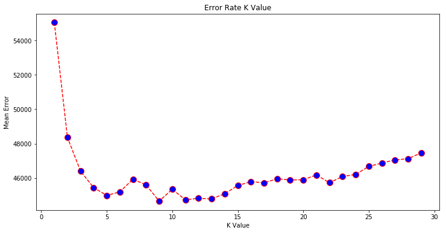

```python
plt.figure(figsize=(12, 6))
plt.plot(range(1, 30), error, color='red', linestyle='dashed', marker='o',
         markerfacecolor='blue', markersize=10)
plt.title('Error Rate K Value')
plt.xlabel('K Value')
plt.ylabel('Mean Error')
```

```
Text(0,0.5,'Mean Error')
```

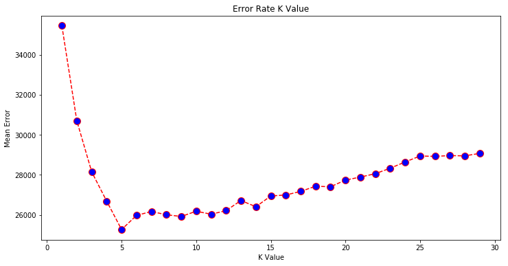

```python
plt.figure(figsize=(12, 6))
plt.plot(range(1, 30), error2, color='red', linestyle='dashed', marker='o',
         markerfacecolor='blue', markersize=10)
plt.title('Error Rate K Value')
plt.xlabel('K Value')
plt.ylabel('Mean Error')
```

### Decision Tree

```python
regressor = DecisionTreeRegressor(max_depth = 3)
regressor.fit(X, y)
y_pred = regressor.predict(X)
result=pd.DataFrame({'Actual':y, 'Predicted':y_pred})
result.head(10)
```

|  | Actual | Predicted |
| --- | --- | --- |
| 0 | 208500 | 194238.744770 |
| 1 | 181500 | 124907.778369 |
| 2 | 223500 | 194238.744770 |
| 3 | 140000 | 194238.744770 |
| 4 | 250000 | 314894.553846 |
| 5 | 143000 | 124907.778369 |
| 6 | 307000 | 249392.466019 |
| 7 | 200000 | 247980.987500 |
| 8 | 129900 | 194238.744770 |
| 9 | 118000 | 124907.778369 |

```python
X = df.iloc[:, :-1].values
y = df.iloc[:, -1].values
X_train, X_test, y_train, y_test = train_test_split(X, y, test_size=0.20)

error = []
error2 = []
# Calculating error for each max-depth values between 1 and 40
for i in range(1, 20):
    regressor = DecisionTreeRegressor(max_depth = i)
    regressor.fit(X_train, y_train)
    y_pred = regressor.predict(X_test)
    error.append( mean_squared_error(y_test, y_pred, squared=False) )
    error2.append( mean_absolute_error(y_test, y_pred))
error2[5]
```

[output not shown]

```
Text(0,0.5,'Mean Error')
```

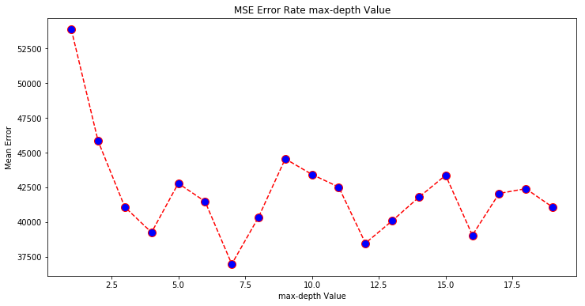

```python
plt.figure(figsize=(12, 6))
plt.plot(range(1, 20), error, color='red', linestyle='dashed', marker='o',
         markerfacecolor='blue', markersize=10)
plt.title('MSE Error Rate max-depth Value')
plt.xlabel('max-depth Value')
plt.ylabel('Mean Error')
```

```
Text(0,0.5,'Mean Error')
```

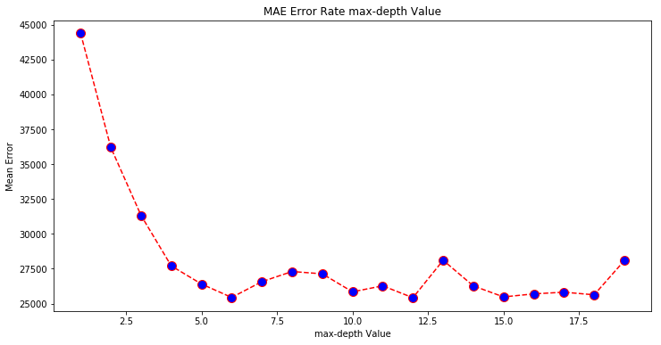

```python
plt.figure(figsize=(12, 6))
plt.plot(range(1, 20), error2, color='red', linestyle='dashed', marker='o',
         markerfacecolor='blue', markersize=10)
plt.title('MAE Error Rate max-depth Value')
plt.xlabel('max-depth Value')
plt.ylabel('Mean Error')
```

### Linear Regressin

Last algorithm which we use for predicting the house prices is **Linear Regression**. Down there, after spliting training dataset, we make a linear regressor in order to predict the prices.

```python
X = df.iloc[:, :-1].values
y = df.iloc[:, -1].values
X_train, X_test, y_train, y_test = train_test_split(X, y, test_size=0.20)

regressor = LinearRegression()
regressor.fit(X_train, y_train)
y_pred = regressor.predict(X)
result=pd.DataFrame({'Actual':y, 'Predicted':y_pred})
result.head(10)
```

|  | Actual | Predicted |
| --- | --- | --- |
| 0 | 208500 | 218470.114188 |
| 1 | 181500 | 197113.464818 |
| 2 | 223500 | 216920.670718 |
| 3 | 140000 | 170076.903228 |
| 4 | 250000 | 289205.468925 |
| 5 | 143000 | 154627.683501 |
| 6 | 307000 | 288436.242827 |
| 7 | 200000 | 232644.767042 |
| 8 | 129900 | 163958.971452 |
| 9 | 118000 | 125092.722765 |

```python
## Error values for Linear regression.
print('Mean Absolute Error:', mean_absolute_error(y, y_pred))
print('Mean Squared Error:', mean_squared_error(y, y_pred, squared=False))
```

```
Mean Absolute Error: 18204.8243197
Mean Squared Error: 28982.2202065
```

## Overfitting and Underfitting

Before looking at underfitting and overfitting lets take a look at two important terms in data science:

**1. Bias:** Assumptions made by a model to make a function easier to learn.  
**2. Variance:** Error that take place when we change the train data using same learning model.

#### Underfitting

Underfitting means that the model we creat for learning the data is not well enough for predicting every new data. It usually takes place when we have less data to train or when our model is linear and our data is not. Underfitting can be avoided by using more data and also reducing the features by feature selection. In other word underfitting is High bias and low variance model.

#### Overfitting

Overfitting means that the model we creat for learning the data trains with a lot of data which causes the model to learn from noises. Then the model does not categorize the data correctly, because of too many details and noise. It accures when the dataset is too huge or our model is too complex. In other word, overfitting is High variance and low bias.

In our code based on results we get, the linear model has the best performance in predicting which helps us understands that our dataset is linear and fits efficiently in the model.

### Pre-Processing Effect

In order to find out the influence of pre-proccessing on our model we use the linear model and compare after pre-processing dataframe with the one without reliable pre-proccessing. So we need to use the simple dataframe.

```python
df_no_preprocess = pd.read_csv('train.csv')
for i in df_no_preprocess:
    if df_no_preprocess[i].dtype == 'object':
        df_no_preprocess[i] = df_no_preprocess[i].astype('category').cat.codes
df_no_preprocess = df_no_preprocess.fillna(0)

X = df_no_preprocess.iloc[:, :-1].values
y = df_no_preprocess.iloc[:, -1].values
X_train, X_test, y_train, y_test = train_test_split(X, y, test_size=0.20)

regressor = LinearRegression()
regressor.fit(X_train, y_train)
y_pred = regressor.predict(X)
print('Mean Absolute Error:', mean_absolute_error(y, y_pred))
print('Mean Squared Error:', mean_squared_error(y, y_pred, squared=False))
```

```
Mean Absolute Error: 18309.6011526
Mean Squared Error: 29573.6058578
```

You can see that fillnig all the null features with 0 increase error values.

```python
df_no_preprocess = pd.read_csv('train.csv')
for i in df_no_preprocess:
    if df_no_preprocess[i].dtype == 'object':
        df_no_preprocess[i] = df_no_preprocess[i].astype('category').cat.codes
df_no_preprocess = df_no_preprocess.dropna()

X = df_no_preprocess.iloc[:, :-1].values
y = df_no_preprocess.iloc[:, -1].values
X_train, X_test, y_train, y_test = train_test_split(X, y, test_size=0.20)

regressor = LinearRegression()
regressor.fit(X_train, y_train)
y_pred = regressor.predict(X)
print('Mean Absolute Error:', mean_absolute_error(y, y_pred))
print('Mean Squared Error:', mean_squared_error(y, y_pred, squared=False))
```

```
Mean Absolute Error: 19069.2781346
Mean Squared Error: 31108.285379
```

Also it is clear that if we handle NA values by dropping the sample, similarly error valus increase.

## Phase 2

### Random Forest

In this part we implement the random forest algorithm.

```python
from sklearn.ensemble import RandomForestRegressor
X = df.iloc[:, :-1].values
y = df.iloc[:, -1].values
X_train, X_test, y_train, y_test = train_test_split(X, y, test_size=0.20)
regressor = RandomForestRegressor(n_estimators=200, random_state=0)
regressor.fit(X_train, y_train)
y_pred = regressor.predict(X_test)
```

```python
print('Mean Absolute Error:', mean_absolute_error(y_test, y_pred))
print('Mean Squared Error:', mean_squared_error(y_test, y_pred, squared=False))
```

```
Mean Absolute Error: 19468.2664212
Mean Squared Error: 36061.1625959
```

Here we want to compare the values of hyperparameter 'random_state' which relate to randomness of samples.

```python
X = df.iloc[:, :-1].values
y = df.iloc[:, -1].values
X_train, X_test, y_train, y_test = train_test_split(X, y, test_size=0.20)
regressor = RandomForestRegressor(n_estimators=200, random_state=1)
regressor.fit(X_train, y_train)
y_pred = regressor.predict(X_test)
print('Mean Absolute Error:', mean_absolute_error(y_test, y_pred))
print('Mean Squared Error:', mean_squared_error(y_test, y_pred, squared=False))
```

```
Mean Absolute Error: 16767.8049829
Mean Squared Error: 23614.1907851
```

```python
X = df.iloc[:, :-1].values
y = df.iloc[:, -1].values
X_train, X_test, y_train, y_test = train_test_split(X, y, test_size=0.20)
regressor = RandomForestRegressor(n_estimators=10, random_state=1)
regressor.fit(X_train, y_train)
y_pred = regressor.predict(X_test)
print('Mean Absolute Error:', mean_absolute_error(y_test, y_pred))
print('Mean Squared Error:', mean_squared_error(y_test, y_pred, squared=False))
```

```
Mean Absolute Error: 20875.9568493
Mean Squared Error: 33236.2710274
```

Similar to *"random_state"* the other hyper-parameter *"n_estimators"* which refer to number of trees making the forest can have great affect on the result. As you see, by increasing the number of trees the accaurcy of prediction increase.

### Voting Regression

```python
from sklearn.ensemble import VotingRegressor
X = df.iloc[:, :-1].values
y = df.iloc[:, -1].values
X_train, X_test, y_train, y_test = train_test_split(X, y, test_size=0.20)

linear_regressor = LinearRegression()
decision_tree_regressor = DecisionTreeRegressor(max_depth = 12)
knn_regressor = KNeighborsRegressor(n_neighbors=8)

er = VotingRegressor([('linear', linear_regressor), ('tree', decision_tree_regressor), ('knn',knn_regressor)])
er.fit(X_train, y_train)
y_pred = er.predict(X_test)
result=pd.DataFrame({'Actual':y_test, 'Predicted':y_pred})
result.head(10)
```

|  | Actual | Predicted |
| --- | --- | --- |
| 0 | 135900 | 122607.419521 |
| 1 | 124900 | 172279.929929 |
| 2 | 168000 | 167589.589348 |
| 3 | 271000 | 251901.326067 |
| 4 | 143750 | 135496.172843 |
| 5 | 210000 | 205795.768917 |
| 6 | 100000 | 98436.805590 |
| 7 | 257500 | 237785.200214 |
| 8 | 139000 | 140920.095101 |
| 9 | 205000 | 233019.824553 |

```python
print('Mean Absolute Error:', mean_absolute_error(y_test, y_pred))
print('Mean Squared Error:', mean_squared_error(y_test, y_pred, squared=False))
```

```
Mean Absolute Error: 18256.379887
Mean Squared Error: 27544.8785599
```

Totally, ensemble models in machine learning work with other algorithms, gather their prediction and decide to choose one of them or creat a mean prediction or even put weight on each prediction and produce a result which working better than each algorithm. To have an insight about it lets take a look at our project different results.

[output not shown]